# Effects of Social Media on Mental Health

#### Team: [ə] Team

#### Authors: Cindy Fu (yuxinfu@uw.edu), Qinghui Xie (qxie@uw.edu), Haipei Chen (hpia22@uw.edu)

#### Affiliation: INFO-201: Technical Foundations of Informatics - The Information School - University of Washington

#### Date: Nov. 14, 2022

## Abstract

Our main question is **understanding how social media affects our mental health**. This question is important because, in our current generation, almost everyone with technology is exposed to social media. To address this, we will create visuals of patterns and correlations between social media use and user characteristics and trends.

## Keywords

health, mental health, social media, technology, depression, withdrawal;

## Introduction

Our project focuses on the effects of social media on mental health. Social media has become very prominent in the last decade creating a place of comfort for some and sadness for others. Through our datasets, we want to showcase how it has affected the majority of the population and create awareness of how much impact social media has on people, especially the current generation that has grown up with exposure to social media. There are different types of social media exposure such as media/current event awareness, lives of individuals, status updates of celebrities, and much more. For many, it may be a personal diary, while others showcase their work. We will be using this project to explore and learn more about these users.

## Problem domain

Over the past decade, social media has been one of the most popular communication tools with approximately 3 billion social media users worldwide. Amongst them, adolescents and young adults are the most active users of social media(Schønning, 2020). From instant messaging to posting life updates, social media allows you not only to share your life with the people you are already close with, but also craft an online image for those who want to get to know you more. This is where the discrepancy lies: an online social media portfolio sometimes does not match how one is like in reality. This leads to teenage problems such as body image issues, imposter syndrome, and comparison of follower counts, which would potentially harm one’s self-esteem and mental health. Research says, “facebook usage increases users' engagement in social comparison and consequently decreases their happiness”(Arad, 2017). These consequences are especially exacerbated by the ongoing COVID-19 pandemic when everyone is isolated in their digital world. Therefore, it is important to investigate the correlation between social media usage and its effects on mental health among teenagers and adolescents.

## Research questions

1. How does social media trends affect the rise or decrease of depression?
- This is the question that is most commonly asked or thought about when using social media. Many parents and guardians don’t allow their children to use social media at a young age because they know of the detrimental effects it can cause to their children.
2. Is there a correlation between the rise of social media usage and teenage mood levels?
- As mentioned in the introduction, social media can bring about happiness or sadness. Which is more prominent is unknown to us which leads us to explore this question with our dataset.
3. Does withdrawal from social media exist and how severe is it?
- Social media is an addiction just like anything else and for every addiction, there may be withdrawals. We want to take a look into what happens after the cease of social media after prolonged use and how it affects individuals differently.
4. How are the young generation, particularly from 17 to 22, influenced by social media both physically and mentally?
- Through data analysis, we wish to understand how social media can influence the physical activities of the young generation. Besides, social media is filled with different information. We want to see how much inappropriate information they have been exposed to that can influence them mentally.

## The dataset

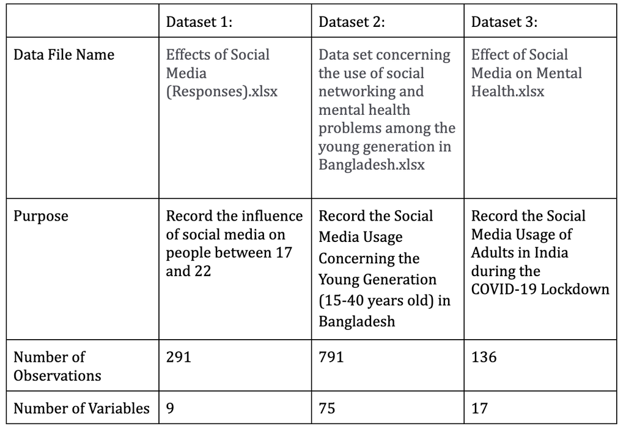

### Dataset 1: Data of Usage of Social Media by Students Between Age 17-22

1. Description: This dataset provides data about the time students on social media and on physical activities. By comparing these two categories of data, we can learn if students are getting enough exercise for their physical well-being. Also, we can use this dataset to understand how much inappropriate content they got from the social media platforms they use. If students are getting too much inappropriate information, it can also influence their mental health condition.
2. Provenance: Maheep Mahat was the creator of this dataset in 2018. There aren’t any people funded for this project. The creator of this project seems to be the only person who benefits from this data. The disappointing news is that we are not sure of either the source or how the creator got this data. Therefore, this data can be not trustworthy. I obtained the data by simply downloading it.

Data of usage of social media by students between age 17-22 - dataset by Maheepmahat. data.world. (2018, September 8). Retrieved October 31, 2022, from https://data.world/maheepmahat/data-of-usage-of-social-media-by-students-between-age-17-22

### Data Set 2: Data of Social Media Usage Concerning the Young Generation (15-40 years old) in Bangladesh

1. Description: This dataset provides information about the social media usage among adolescents. By organizing the information and sorting the observations into age groups, it is possible to find the correlation between mental health and social media usage. The data provided are qualitative and quantitative data that is possible to make inferences about the effects of social media.
2. Provenance: Researchers from the University of Asia Pacific, Dhaka, have collected data from across Bangladesh. The dataset is the raw data that researchers have collected to investigate how mental health problems in the young generation in Bangladesh correlate to their social media usage. The data collected were responses to self-reported questionnaires using Google Surveys. The questionnaire was sent to participants through digital communication tools such as e-mail, Instagram, Facebook Messenger, etc. Though participants weren’t filtered and it was a random sample of subjects who are willing to participate, the dataset is supplementary to the research questions that were being proposed due to the large sample size and the wide range of backgrounds of participants.

Islam, Md. Rabiul, et al. “Data Set Concerning the Use of Social Networking Sites and Mental Health Problems among the Young Generation in Bangladesh.” Data in Brief, Elsevier, 19 Nov. 2021, https://www.sciencedirect.com/science/article/pii/S2352340921008684#tbl0001.

### Data Set 3: Effect of social media on mental health during Covid-19 lockdowns in India

1. Description: This dataset provides information about the social media usage of adults in India during the COVID-19 pandemic lockdown. By organizing this data with respect to the age groups, it is possible to infer the correlation between mental health issues and social media usage in adolescents. However, the data might have a potential bias as in the participants were in lockdown. The isolation factor might also contribute as a factor to the mental health issues, which would be difficult to make inferences with basic sorting and filtering techniques.
2. Provenance: This dataset is collected by researchers Saptorshi Gupta and Ayan Ganguly. The objective of this dataset is to analyze both the positive and negative effects of social media usage on individuals in India during a global lockdown. It is specifically concerned with second deadly COVID-19 pandemic wave in India and to understand the extent of depression and anxiety caused by social media and the lockdown. The data is collected by sending questionaires to participants during the lockdown through online platforms, without specific samples as to the socioeconomic status of the participants.

Gupta, Saptorshi, and Ayan Ganguly. “Effect of Social Media on Mental Health during Covid-19 Lockdowns in India.” Zenodo, 16 Sept. 2021, https://zenodo.org/record/5512843#.Y2C1HOzMKqV.

## Discussion:

This study on social media and its negative effects raise an important question of the ethics and purpose of social media, or even the advancement of technology. Nowadays, there are many social media platforms that people use. Facebook was founded in 2004, Instagram was founded six years after, and now we have Snapchat and BeReal… approximately every ten years, a new digital platform will blow up with newcoming generation. However, many features on these platforms are designed to get people addicted. For example, the for-you pages we see on our feed is generated by the social media algorithm, and it curates content that would get you hooked on your phone for the next two hours. The interactive design of these applications creates such smooth communication features that would give users a comfortable environment to express themselves. This not only is one of the causes for high social media usage, but it also restricts users in their own comfort zones of their own knowledge, preventing progress in society.  
Going off of the previous point, this also raises concerns about the deteriorating mental health in the young generations. Adolescence and adulting is a special time where young adults form an understanding of the world. They grow physically, socially, and emotionally, whilst they are also exposed to the cruel side of the world like poverty, abuse, etc. Adolescence is a very vulnerable period of time, and young adults would need the support from friends and family. However, social media has increased the severity their mood swings as well as emotional stability, which is a concern for stakeholders such as influencers, content creators, and social media companies.  
So with all of these considerations, does this mean that we should complete cut out social media? The answer is no. The implication of this study is that we would have to go into social media with the correct mindset and habits While social media has led to many mental health issues, it is also a digital platform that allows users to explore current trends, get updated on the most recent news, and stay connected with their closest friends. It is important to acknowledge that social media, like all other entertainment activities, should have a limit in which you should hold yourself accountable. Whether its screen time or a change in mindset, it is important to use social media as a healthy tool to connect and explore.

## Conclusion:

Throughout this research, we analyzed datasets and cited previous studies to prove that social media has exacerbated people’s preexisting mental health issues. It is important to acknowledge the negative impact and take action accordingly to counter these issues. Social media allows people to create an online profile for themselves, but this sometimes gives people unrealistic views of others’ lives, which lead to problems of comparing one to another. Here, it is important to have a correct mindset and acknowledge the fact that the things people post are only a small part of their life. We don’t see how people are struggling behind the flawless filters and curated captions.  
In addition, social media has also been a distraction and disruption to a healthy lifestyle. Features such as for-you pages would only distract one briefly from reality and take away time from one which they can use it better to advance themselves. It is necessary to understand and have a limit of how much time one spends on social media in order to block out the distractions. On the other hand, research shows that bluelight from electronic devices would disrupt one’s sleeping pattern and make it more difficult to fall asleep, which indirectly impacts our physical health as well.  
With all the factors added up, it is not surprising that social media would be one of the factors that lead to anxiety and depression. Therefore, it is important to understand the pros of social media, or even seek alternative solutions to take your time away from social media. For instance, social media is a great tool to build online communities without the restriction of geographical boundaries. People get exposed to new hobbies, or even find a friend from another country that has the same interests as them. This could be helpful for those who experience exclusion or disabilities, where they are incapable of getting out of their comfort zone and having an enjoyable social life.  
Furthermore, social media can also be used for self-expression and entertainment. Many people showcase their interests on social media by posting photos and videos of their progress, which will also attract other people to explore these new activities. Entertainment resources online is also a great way to take a break from reality, which is beneficial for mental health problems such as anxiety and depression.  
In short, while social media has influenced one’s mental health in one way another, it is in fact a creative and advanced communication tool in the 21st century. In order to combat these negative influences, we should do our part to use social media as a tool that would help us learn and grow.

## Acknowledgement:

Thank you to this team who is reliable and flexible.

## References:

- Arad, A., Barzilay, O., & Perchick, M. (2017, February 13). The impact of facebook on social comparison and happiness: Evidence from a natural experiment. SSRN. Retrieved October 31, 2022, from https://papers.ssrn.com/sol3/papers.cfm?abstract_id=2916158
- Barasch, A., Zauberman, G., & Diehl, K. (2017, November 14). How the intention to share can undermine enjoyment: Photo-taking goals and evaluation of experiences. OUP Academic. Retrieved October 31, 2022, from https://academic.oup.com/jcr/article/44/6/1220/4627834?login=false
- Schønning, V., Hjetland, G. J., Aarø, L. E., & Skogen, J. C. (2020, August 14). Data_Sheet_1_Social media use and mental health and well-being among adolescents – a scoping review.docx. figshare. Retrieved October 31, 2022, from https://figshare.com/articles/dataset/Data_Sheet_1_Social_Media_Use_and_Mental_Health_and_Well-Being_Among_Adolescents_A_Scoping_Review_docx/12806267/1